# UDACITY R Data Analysis Lesson 5

### Lesson 5.9: Quiz: Conditional Means - dplyr

```r
age_groups <- group_by(pf, age)
pf.fc_by_age <- summarise(age_groups,
          fc_mean = mean(friend_count),
          fc_median = median(friend_count),
          n = n()
          )
pf.fc_by_age
```

| age | fc_mean | fc_median | n |
| --- | --- | --- | --- |
| 13 | 164.75000 | 74.0 | 484 |
| 14 | 251.39013 | 132.0 | 1925 |
| 15 | 347.69213 | 161.0 | 2618 |
| 16 | 351.93714 | 171.5 | 3086 |
| 17 | 350.30064 | 156.0 | 3283 |
| 18 | 331.16628 | 162.0 | 5196 |
| 19 | 333.69210 | 157.0 | 4391 |
| 20 | 283.49907 | 135.0 | 3769 |
| 21 | 235.94116 | 121.0 | 3671 |
| 22 | 211.39479 | 106.0 | 3032 |

[output cut: 91 more lines]

```r
# Performs the same operation as the previous code cell
pf.fc_by_age <- pf %>%
  group_by(age) %>%
  summarise(fc_mean = mean(friend_count),
            fc_median = median(friend_count),
            n = n())
pf.fc_by_age
```

| age | fc_mean | fc_median | n |
| --- | --- | --- | --- |
| 13 | 164.75000 | 74.0 | 484 |
| 14 | 251.39013 | 132.0 | 1925 |
| 15 | 347.69213 | 161.0 | 2618 |
| 16 | 351.93714 | 171.5 | 3086 |
| 17 | 350.30064 | 156.0 | 3283 |
| 18 | 331.16628 | 162.0 | 5196 |
| 19 | 333.69210 | 157.0 | 4391 |
| 20 | 283.49907 | 135.0 | 3769 |
| 21 | 235.94116 | 121.0 | 3671 |
| 22 | 211.39479 | 106.0 | 3032 |

[output cut: 91 more lines]

Plot mean friend count vs. age using a line graph. Be sure you use the correct variable names and the correct data frame. You should be working with the new data frame created from the dplyr functions. The data frame is called ‘pf.fc_by_age’.

Use geom_line() rather than geom_point to create the plot. You can look up the documentation for geom_line() to see what it does.

```r
p_pf_mean_fc <- ggplot(data = pf.fc_by_age, aes(x = age, y = fc_mean, color = age)) +
  geom_point(show.legend = FALSE) +
  scale_color_gradientn(colors = rainbow(21)) +
  ylab("Friend Count Mean") + xlab("Age") +
  scale_x_continuous(limits = c(13, 90), breaks = seq(10, 90, 5)) +
  scale_y_continuous(limits = c(75, 425), breaks = seq(75, 425, 25)) +
  geom_hline(yintercept=100, color='#0033FF', linetype=3)
```

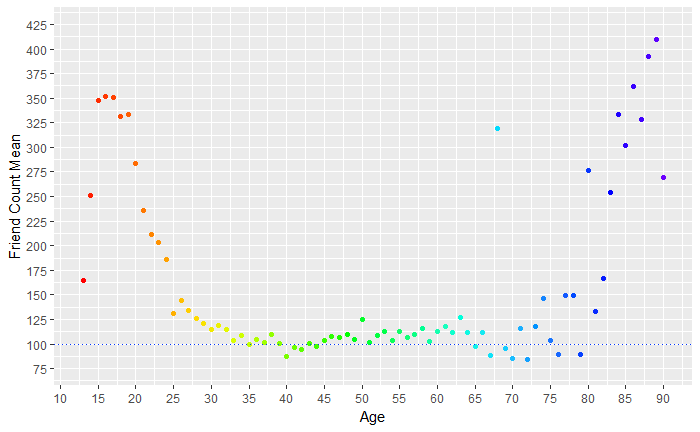

```r
p_pf_mean_fc
```

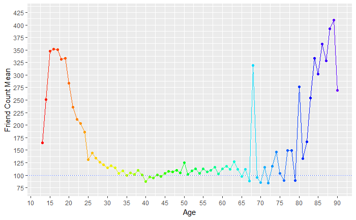

```r
p_pf_mean_fc +
  geom_line(show.legend = FALSE)
```

### Lesson 5.10: Quiz: Overlaying Summaries with Raw Data

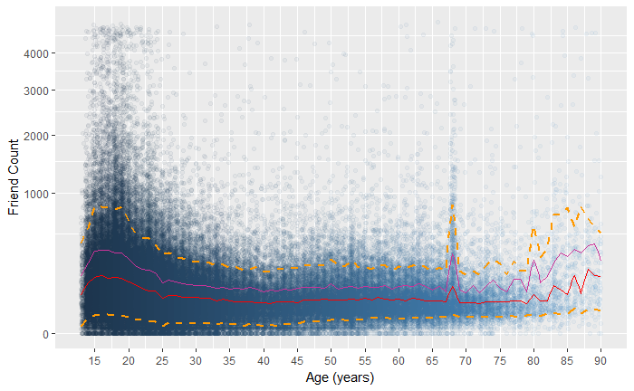

```r
p_pf_overlay <- p_pf +
  geom_point(alpha = 1/20, position = position_jitter(h = 0), show.legend = FALSE) +
  scale_x_continuous(limits = c(13, 90), breaks = seq(10, 90, 5)) +
  xlab("Age (years)") + ylab("Friend Count") +
  coord_trans(y = "sqrt") +
  geom_line(stat = "summary", fun.y = mean, color="#CC3399") +
  geom_line(stat = "summary", fun.y = quantile, fun.args = list(probs = 1/10), linetype = 2, color="#FF9900", size = 1) +
  geom_line(stat = "summary", fun.y = quantile, fun.args = list(probs = 1/2), color="red") +
  geom_line(stat = "summary", fun.y = quantile, fun.args = list(probs = 9/10), linetype = 2, color="#FF9900", size = 1)
p_pf_overlay
```

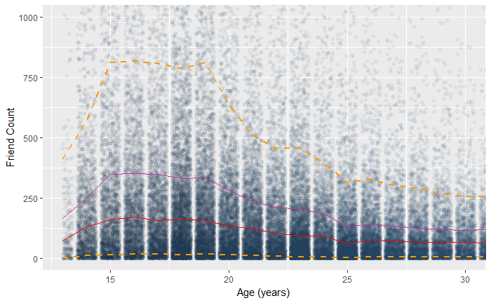

```r
p_pf_overlay +
  coord_cartesian(xlim = c(13, 30), ylim = c(0,1000))
```

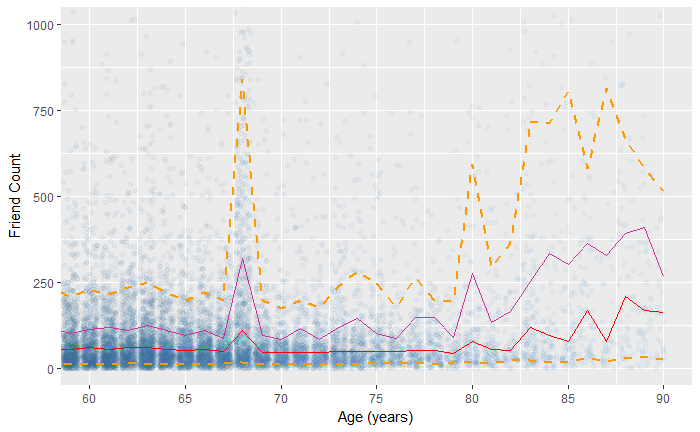

```r
p_pf_overlay +
  coord_cartesian(xlim = c(60, 90), ylim = c(0,1000))
```

### Lesson 5.12: Quiz: Correlation

```r
cor.test(pf$age, pf$friend_count, method = "pearson")
```

```
    Pearson's product-moment correlation

data:  pf$age and pf$friend_count
t = -8.6268, df = 99001, p-value < 2.2e-16
alternative hypothesis: true correlation is not equal to 0
95 percent confidence interval:
 -0.03363072 -0.02118189
sample estimates:
        cor
-0.02740737
```

```r
with(pf, cor.test(age, friend_count, method = "pearson"))
```

```
    Pearson's product-moment correlation

data:  age and friend_count
t = -8.6268, df = 99001, p-value < 2.2e-16
alternative hypothesis: true correlation is not equal to 0
95 percent confidence interval:
 -0.03363072 -0.02118189
sample estimates:
        cor
-0.02740737
```

### Lesson 5.13: Quiz: Correlation on Subsets

```r
with(subset(pf, age <= 30), cor.test(age, friend_count, method = "pearson"))
```

```
    Pearson's product-moment correlation

data:  age and friend_count
t = -40.839, df = 53396, p-value < 2.2e-16
alternative hypothesis: true correlation is not equal to 0
95 percent confidence interval:
 -0.1822498 -0.1658000
sample estimates:
      cor
-0.174037
```

### Lesson 5.15: Quiz: Create Scatterplots

Create a scatterplot of likes_received (y) vs. www_likes_received (x). Use any of the techniques that you’ve learned so far to modify the plot.

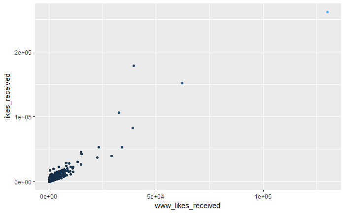

```r
p_pf_likes <- ggplot(data = pf, aes(x = www_likes_received, y = likes_received)) +
  geom_point(aes(color=www_likes_received), show.legend = FALSE)
p_pf_likes
```

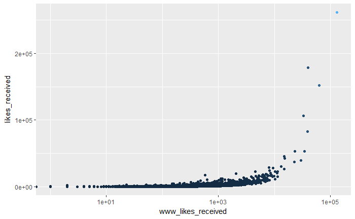

```r
 p_pf_likes +
  scale_x_log10()
```

Resourses:

1. http://ggplot2.tidyverse.org/reference/annotation_logticks.html

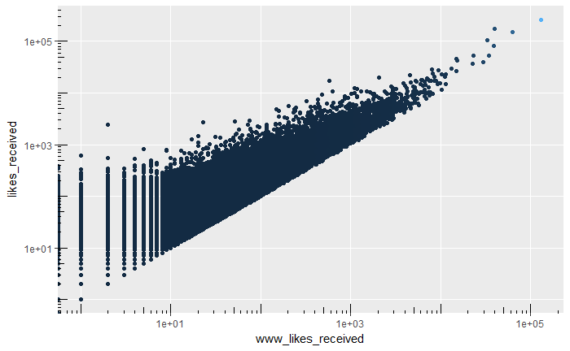

```r
p_pf_likes +
  scale_x_log10() + scale_y_log10() +
  annotation_logticks()
```

### Lesson 5.16: Quiz: Strong Correlations

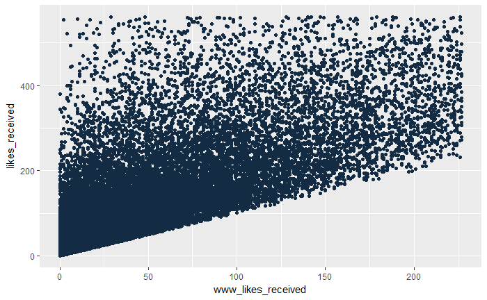

```r
p_pf_likes +
  xlim(0, quantile(pf$www_likes_received, 0.95)) +
  ylim(0, quantile(pf$likes_received, 0.95))
```

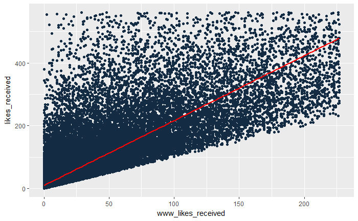

```r
p_pf_likes +
  xlim(0, quantile(pf$www_likes_received, 0.95)) +
  ylim(0, quantile(pf$likes_received, 0.95)) +
  geom_smooth(method = "lm", color = "red", size = 1)
```

```r
with(pf, cor.test(www_likes_received, likes_received, method = "pearson"))
```

```
    Pearson's product-moment correlation

data:  www_likes_received and likes_received
t = 937.1, df = 99001, p-value < 2.2e-16
alternative hypothesis: true correlation is not equal to 0
95 percent confidence interval:
 0.9473553 0.9486176
sample estimates:
      cor
0.9479902
```

### Lesson 5.18: Quiz: More Caution with Correlation

Create a scatterplot of temperature (Temp) vs. months (Month).

```r
data("Mitchell")
?Mitchell
```

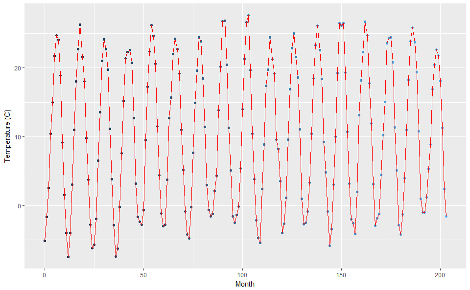

```r
p_Mitchell <- ggplot(data = Mitchell, aes(y = Temp, x = Month, color = Month)) +
  geom_point(show.legend = FALSE) +
  ylab("Temperature (C)") + xlab("Month") +
  geom_line(show.legend = FALSE, color = "red")
p_Mitchell
```

```r
months <- c('January',
          'February',
          'March',
          'April',
          'May',
          'June',
          'July',
          'August',
          'September',
          'October',
          'November',
          'December')
years <- c(1976, 1977, 1978, 1979, 1980,
         1981, 1982, 1983, 1984, 1985,
         1986, 1987, 1988, 1989, 1990,
         1991, 1992)
y_m <- c()
my_year <- c()
my_month <- c()
for(i in years){
  for(j in months){

    y_m <- c(y_m, paste(i,j, sep = ", "))
    my_year <- c(my_year, i)
    my_month <- c(my_month, j)
  }
}
```

```r
my_mitchell <- Mitchell
my_mitchell["Month_Name"] <- my_month
my_mitchell["Year"] <- my_year
my_mitchell$Month_Name <- factor(my_mitchell$Month_Name,
                                 levels = months,
                                 ordered = TRUE)
```

```r
my_month_num <- match(my_month, month.name)
my_mitchell["Month_Num"] <- my_month_num
```

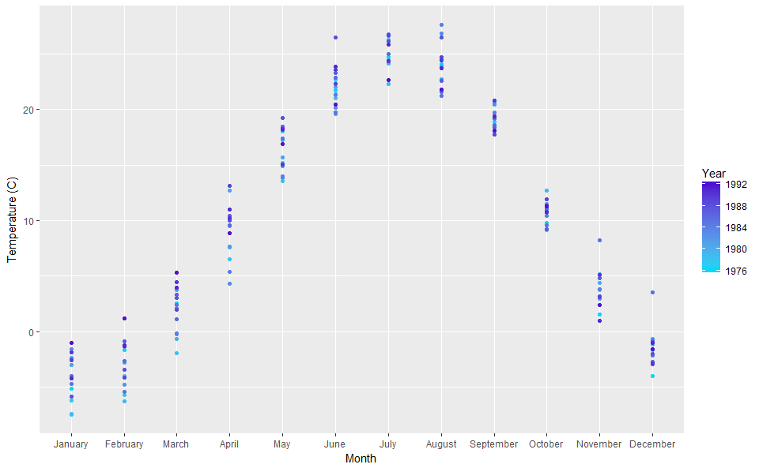

```r
p_Mitchell_2 <- ggplot(data = my_mitchell, aes(y = Temp, x = Month_Name, color = Year)) +
  geom_point(show.legend = TRUE) +
  ylab("Temperature (C)") + xlab("Month") +
  scale_color_gradient(low='#05D9F6', high='#5011D1')
p_Mitchell_2
```

Resource:

1. https://www.hexcolortool.com/#9580ff

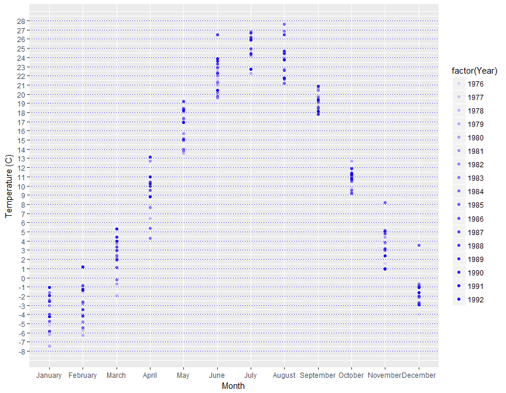

```r
ggplot(data = my_mitchell, aes(y = Temp, x = Month_Name, color = factor(Year))) +
  geom_point(show.legend = TRUE) +
  ylab("Temperature (C)") + xlab("Month") +
  scale_color_manual(values = c("1976" = "#E1CCFF", "1977" = "#D4BFFF", "1978" = "#C8B3FF", "1979" = "#BAA5FF",
                                "1980" = "#AE99FF", "1981" = "#A18CFF", "1982" = "#947FFF", "1983" = "#8873FF",
                                "1984" = "#7B66FF", "1985" = "#6E59FF", "1986" = "#624DFF", "1987" = "#5540FF",
                                "1988" = "#4833FF", "1989" = "#3B26FF", "1990" = "#2F1AFF", "1991" = "#220DFF",
                                "1992" = "#1500FF")) +
  scale_y_continuous(limits = c(-8, 28), breaks = seq(-8, 28, 1)) +
  geom_hline(yintercept = seq(-8, 28, 1), color = 'blue', linetype = 3)
```

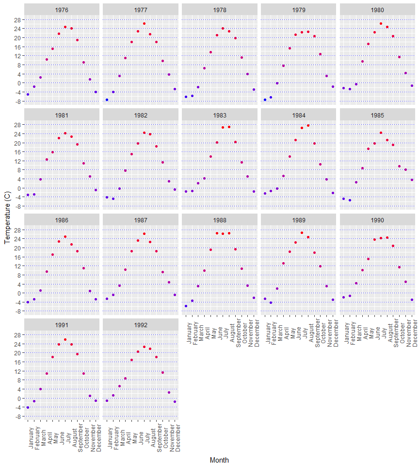

```r
ggplot(data = my_mitchell, aes(y = Temp, x = Month_Name, color = Temp)) +
  geom_point(show.legend = FALSE) +
  ylab("Temperature (C)") + xlab("Month") +
  facet_wrap(~Year) +
  theme(axis.text.x = element_text(angle = 90)) +
  scale_y_continuous(limits = c(-8, 28), breaks = seq(-8, 28, 4)) +
  geom_hline(yintercept = seq(-8, 28, 4), color = 'blue', linetype = 3) +
  scale_color_gradient(low = "blue", high = "red")
```

```r
summary(my_mitchell$Temp)
```

```
   Min. 1st Qu.  Median    Mean 3rd Qu.    Max.
-7.4778 -0.3486 10.4500 10.3125 20.4306 27.6056
```

```r
my_mitchell %>%
  group_by(Year) %>%
  summarise(min(Temp),
            max(Temp),
            mean(Temp))
```

| Year | min(Temp) | max(Temp) | mean(Temp) |
| --- | --- | --- | --- |
| 1976 | -5.18333 | 24.7444 | 9.762955 |
| 1977 | -7.47778 | 26.2611 | 9.987963 |
| 1978 | -6.18889 | 24.1833 | 8.828711 |
| 1979 | -7.42222 | 22.5611 | 9.169444 |
| 1980 | -2.82778 | 26.2000 | 10.785638 |
| 1981 | -2.99444 | 24.2389 | 10.818049 |
| 1982 | -4.78889 | 24.4667 | 9.450010 |
| 1983 | -1.59444 | 26.8778 | 10.533340 |
| 1984 | -2.49444 | 27.6056 | 10.215741 |
| 1985 | -5.46111 | 24.4667 | 10.356952 |

[output cut: 7 more lines]

```r
subset(my_mitchell, Temp == max(Temp))
```

|  | Month | Temp | Month_Name | Year | Month_Num |
| --- | --- | --- | --- | --- | --- |
| 104 | 103 | 27.6056 | August | 1984 | 8 |

```r
subset(my_mitchell, Temp == min(Temp))
```

|  | Month | Temp | Month_Name | Year | Month_Num |
| --- | --- | --- | --- | --- | --- |
| 13 | 12 | -7.47778 | January | 1977 | 1 |

```r
my_mitchell %>%
  summarise(min(Temp),
            max(Temp),
            mean(Temp))
```

| min(Temp) | max(Temp) | mean(Temp) |
| --- | --- | --- |
| -7.47778 | 27.6056 | 10.3125 |

```r
my_mitchell %>%
  group_by(Month_Name) %>%
  summarise(min(Temp),
            max(Temp),
            mean(Temp))
```

| Month_Name | min(Temp) | max(Temp) | mean(Temp) |
| --- | --- | --- | --- |
| January | -7.477780 | -1.05000 | -3.935621 |
| February | -6.305560 | 1.20000 | -2.863399 |
| March | -1.933330 | 5.30556 | 1.976798 |
| April | 4.288890 | 13.16110 | 9.229736 |
| May | 13.538900 | 19.22780 | 16.346076 |
| June | 19.588900 | 26.50560 | 22.049676 |
| July | 22.277800 | 26.81670 | 25.130712 |
| August | 21.216700 | 27.60560 | 23.718641 |
| September | 17.783300 | 20.84440 | 19.257512 |
| October | 9.166670 | 12.69440 | 10.835294 |

[output cut: 2 more lines]

### Lesson 5.19: Quiz: Noisy Scatterplots

```r
with(my_mitchell, cor.test(Month, Temp, method = "pearson"))
```

```
    Pearson's product-moment correlation

data:  Month and Temp
t = 0.81816, df = 202, p-value = 0.4142
alternative hypothesis: true correlation is not equal to 0
95 percent confidence interval:
 -0.08053637  0.19331562
sample estimates:
       cor
0.05747063
```

### Lesson 5.20: Quiz: Making Sense of Data

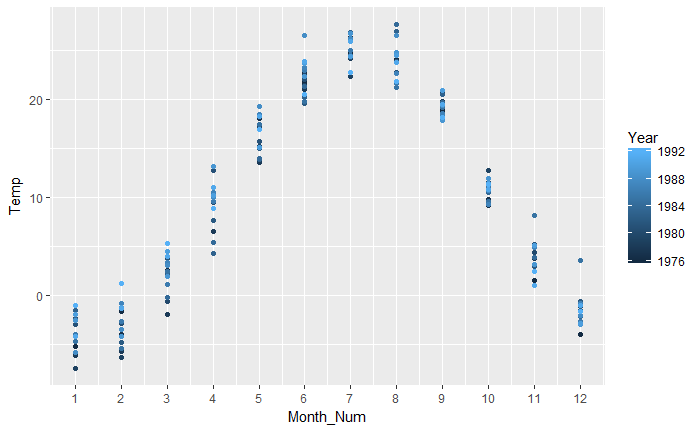

```r
ggplot(data = my_mitchell, aes(y = Temp, x = Month_Num, color = Year)) +
  geom_point(show.legend = TRUE) +
  scale_x_continuous(breaks = seq(1, 12, 1))
```

```r
with(my_mitchell, cor.test(Month_Num, Temp, method = "pearson"))
```

```
    Pearson's product-moment correlation

data:  Month_Num and Temp
t = 3.7341, df = 202, p-value = 0.000245
alternative hypothesis: true correlation is not equal to 0
95 percent confidence interval:
 0.1209562 0.3782722
sample estimates:
      cor
0.2541052
```

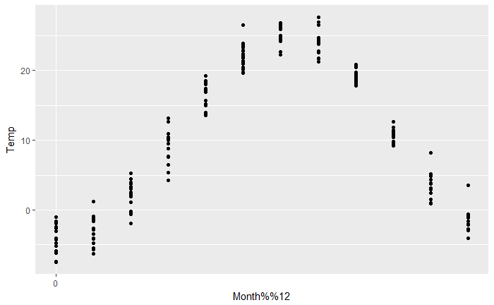

```r
#Udacity Instructor method
ggplot(data = Mitchell, aes(y = Temp, x = Month%%12)) +
  geom_point(show.legend = TRUE) +
  scale_x_continuous(breaks = seq(0, 203, 12))
```

### Lesson 5.21: Quiz: A New Perspective

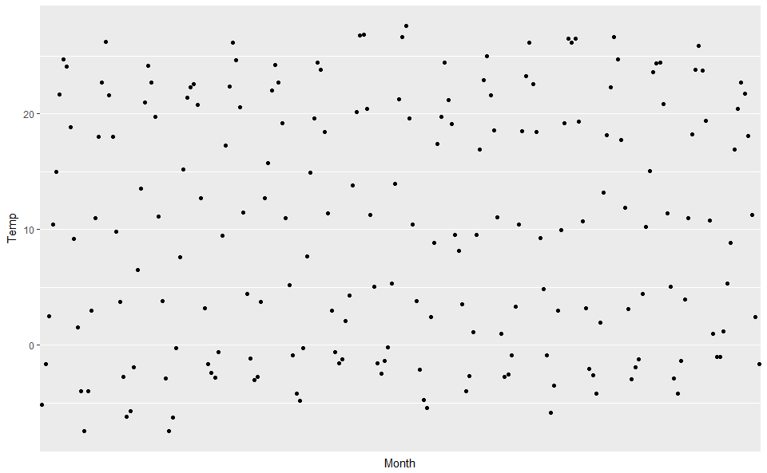

```r
ggplot(data = Mitchell, aes(y = Temp, x = Month)) +
  geom_point() +
  scale_x_discrete(breaks = seq(0, 203, 12))
```

### Lesson 5.22: Quiz: Understanding Noise: Age to Age Months

Create a new variable, ‘age_with_months’, in the ‘pf’ data frame. Be sure to save the variable in the data frame rather than creating a separate, stand-alone variable. You will need to use the variables ‘age’ and ‘dob_month’ to create the variable ‘age_with_months’.

Assume the reference date for calculating age is December 31, 2013.

This programming assignment WILL BE automatically graded. For this exercise, you need only create the ‘age_with_months’ variable; no further processing of the data frame is necessary.

```r
pf <- read.csv("pseudo_facebook.tsv", sep = "\t")
```

```r
# either option below is acceptable
# pf$age_with_months <- pf$age + (1 - dob_month/12)
pf$age_with_months <- with(pf, age + 1 - dob_month/12)
```

### Lesson 5.23: Quiz: Age with Months Means

Create a new data frame called pf.fc_by_age_months that contains the mean friend count, the median friend count, and the number of users in each group of age_with_months. The rows of the data framed should be arranged in increasing order by the age_with_months variable.

#### Solution

```r
pf.fc_by_age_months <- pf %>%
  group_by(age_with_months) %>%
  summarise(friend_count_mean = mean(friend_count),
            friend_count_median = median(friend_count),
            n = n()) %>%
  arrange(age_with_months)
head(pf.fc_by_age_months)
```

| age_with_months | friend_count_mean | friend_count_median | n |
| --- | --- | --- | --- |
| 13.16667 | 46.33333 | 30.5 | 6 |
| 13.25000 | 115.07143 | 23.5 | 14 |
| 13.33333 | 136.20000 | 44.0 | 25 |
| 13.41667 | 164.24242 | 72.0 | 33 |
| 13.50000 | 131.17778 | 66.0 | 45 |
| 13.58333 | 156.81481 | 64.0 | 54 |

#### Alternate Solution

```r
age_with_months_groups <- group_by(pf, age_with_months)
pf.fc_by_age_months2 <- summarise(age_with_months_groups,
                                  friend_count_mean = mean(friend_count),
                                  friend_count_median = median(friend_count),
                                  n = n())
pf.fc_by_age_months2 <- arrange(pf.fc_by_age_months2, age_with_months)
```

### Lesson 5.24: Quiz: Noise in Conditional Means

Create a new line plot showing friend_count_mean versus the new variable, age_with_months. Be sure to use the correct data frame (the one you created in the last exercise) AND subset the data to investigate users with ages less than 71.

```r
summary(subset(pf.fc_by_age_months, age_with_months < 71))
```

```
 age_with_months friend_count_mean friend_count_median       n
 Min.   :13.17   Min.   : 46.33    Min.   : 23.50      Min.   :  6.0
 1st Qu.:27.60   1st Qu.: 94.35    1st Qu.: 52.00      1st Qu.: 68.0
 Median :42.04   Median :114.49    Median : 61.00      Median : 85.0
 Mean   :42.04   Mean   :146.51    Mean   : 74.10      Mean   :131.2
 3rd Qu.:56.48   3rd Qu.:161.07    3rd Qu.: 78.88      3rd Qu.:168.8
 Max.   :70.92   Max.   :421.60    Max.   :214.00      Max.   :913.0
```

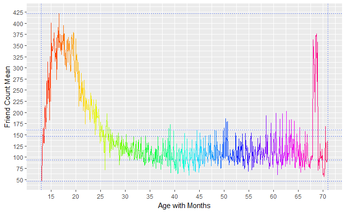

```r
p_pf_age_months <- ggplot(subset(pf.fc_by_age_months, age_with_months < 71),
                          aes(x = age_with_months, y = friend_count_mean, color = age_with_months)) +
  geom_line(show.legend = FALSE) +
  scale_color_gradientn(colors = rainbow(21)) +
  ylab("Friend Count Mean") + xlab("Age with Months") +
  scale_x_continuous(limits = c(13, 71), breaks = seq(10, 75, 5)) +
  scale_y_continuous(limits = c(45, 425), breaks = seq(50, 425, 25)) +
  geom_hline(yintercept=c(146.51, 421.60, 46.33, 94.25, 161.07), color='#0033FF', linetype=3) +
  geom_vline(xintercept=c(13, 71), color='#0033FF', linetype=3)
p_pf_age_months
```

```r
#add rows with same names as pf.fc_by_age_months
pf.fc_by_age$age_with_months <- pf.fc_by_age$age
pf.fc_by_age$friend_count_mean <- pf.fc_by_age$fc_mean
```

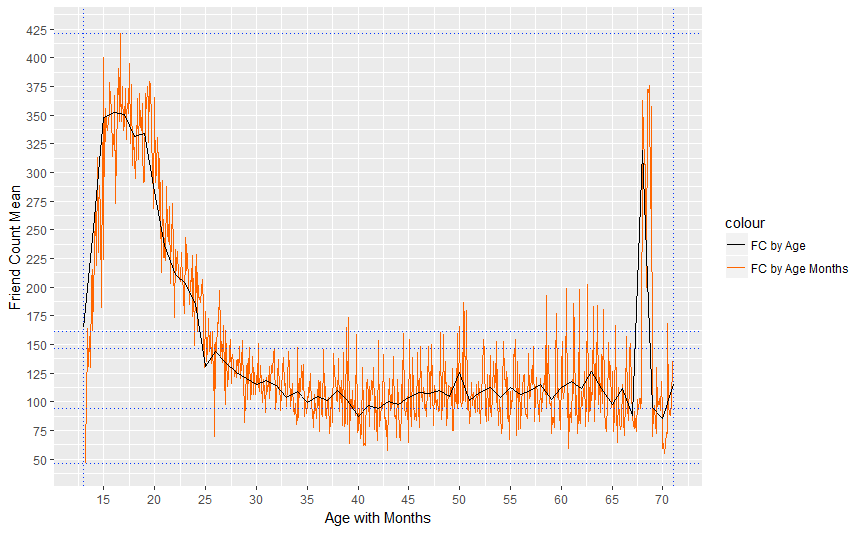

```r
ggplot(subset(pf.fc_by_age_months, age_with_months < 71), aes(x = age_with_months, y = friend_count_mean, color = "FC by Age Months")) +
  geom_line(show.legend = TRUE) +
  ylab("Friend Count Mean") + xlab("Age with Months") +
  scale_x_continuous(limits = c(13, 71), breaks = seq(10, 75, 5)) +
  scale_y_continuous(limits = c(45, 425), breaks = seq(50, 425, 25)) +
  geom_hline(yintercept=c(146.51, 421.60, 46.33, 94.25, 161.07), color='#0033FF', linetype=3) +
  geom_vline(xintercept=c(13, 71), color='#0033FF', linetype=3) +
  geom_line(data = pf.fc_by_age, aes(x = age_with_months, y = friend_count_mean, color="FC by Age"), show.legend = FALSE) +
  scale_color_manual(values = c("FC by Age" = "black", "FC by Age Months" = "#FF6600"))
```

### Lesson 5.25: Smoothing Conditional Means

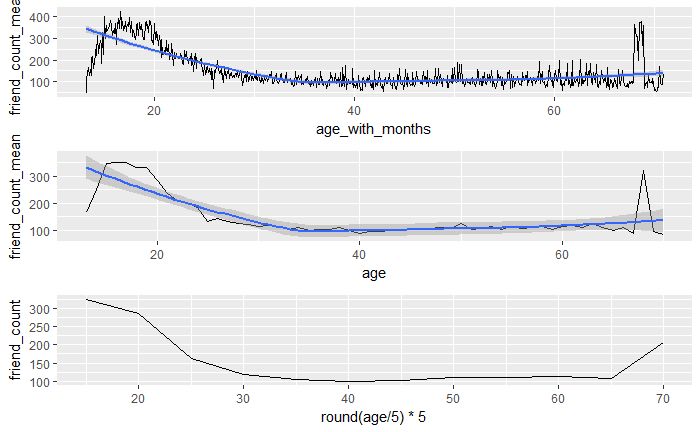

```r
p1 <- ggplot(aes(x = age, y = friend_count_mean), data = subset(pf.fc_by_age, age < 71)) +
  geom_line() +
  geom_smooth()
p2 <- ggplot(aes(x = age_with_months, y = friend_count_mean), data = subset(pf.fc_by_age_months, age_with_months < 71)) +
  geom_line() +
  geom_smooth()
p3 <- ggplot(aes(x = round(age /5) * 5, y = friend_count), data = subset(pf, age < 71)) +
  geom_line(stat = "summary", fun.y = mean)
grid.arrange(p2, p1, p3, ncol = 1)
```